# Three Age-Group Analysis - With SCI

## Library and Data

```r
library(survival)
library(tidyverse)
library(penalized)
library(kableExtra)
library(ggrepel)

source("../R/utils.R")
source("../R/full_helper.R")
source("../R/lasso_helper.R")
source("../R/stepBIC_helper.R")
source("../R/cumulative_helper.R")

raw_data <- read_csv("../data/Aim3-early-adversity-subjects-F-survival-2021-01-29.csv")
raw_data <- dplyr::select(raw_data, -c("adv_mom_dsi", "adv_cumulative"))
```

Raw data here refers to the larger dataset.

## EDA

Below is the Kaplan-Meier estimation of the survival function on the raw data.

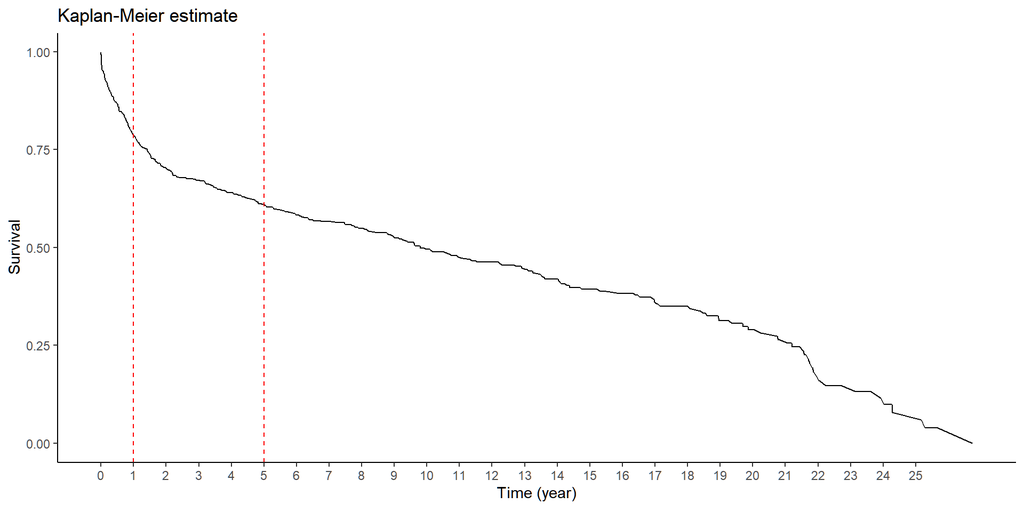

```r
km <- survfit(Surv(raw_data$age, raw_data$dead) ~ 1, conf.type = "log-log")
ggplot() +
  geom_line(aes(x = km$time, y = km$surv)) +
  geom_vline(aes(xintercept = 1), color = "red", linetype = "dashed") +
  geom_vline(aes(xintercept = 5), color = "red", linetype = "dashed") +
  labs(x = expression("Time (year)"), y = expression("Survival"),
       title = "Kaplan-Meier estimate") +
  scale_x_continuous(breaks = seq(0, 25, 1)) +
  theme_classic()
```

## Analysis Process

We conduct four models on three datasets derived from the raw data.

Four models:

- Cox model of survival data versus all the main effects (six adversities)
- Cox model of survival data versus main effects and interaction terms selected by lasso
- Cox model of survival data versus main effects and interaction terms selected by stepwise BIC
- Cox model of survival data versus `adv_mom`, sum of other adversities `adv_other_cumulative` and their interaction term

Three datasets:

- `age_below_1`: Include all the samples. For those whose `age` > 1, use `age` = 1, and `dead` = FALSE
- `age_above_1_below_5`: Include samples of `age` > 1. For those whose `age` > 5, use `age` = 5, and `dead` = FALSE
- `age_above_5`: Include samples of `age` > 5.

Note that for the `age_below_1` dataset, we exclude `adv_sib` from all models.

## Modification of the Covariates

First, we replace **low maternal DSI** with **low maternal SCI**.

And brief information of covariates we are using in this analysis is in the table below:

```r
covariate_names <- c("adv_density", "adv_rain", "adv_mom",
                     "adv_sib", "adv_mom_rank", "adv_mom_sci",
                     "adv_cumulative_sci")
covariate_types <- c(rep("Logical", 6), "Numeric")
covariate_meanings <- c("Group size is in the highest quartile",
                       "Rainfall <= 200mm",
                       "Mom dies before age 4",
                       "A sibling is born",
                       "Mom's rank is in the lowest quartile",
                       "Social connection is in the lowest quartile",
                       "Sum of the above six adversities")

data.frame(
  list(types = covariate_types,
       meanings = covariate_meanings)
) %>%
  `row.names<-`(covariate_names) %>%
  kable(col.names = c("Type", "Meaning if TRUE")) %>%
  kable_styling(full_width = FALSE, position = "center", font_size = 18)
```

|  | Type | Meaning if TRUE |
| --- | --- | --- |
| adv_density | Logical | Group size is in the highest quartile |
| adv_rain | Logical | Rainfall <= 200mm |
| adv_mom | Logical | Mom dies before age 4 |
| adv_sib | Logical | A sibling is born |
| adv_mom_rank | Logical | Mom’s rank is in the lowest quartile |
| adv_mom_sci | Logical | Social connection is in the lowest quartile |
| adv_cumulative_sci | Numeric | Sum of the above six adversities |

```r
age_below_1 <- raw_data %>%
  select(starts_with("adv_"), age, dead, -adv_cumulative_sci) %>%
  mutate(dead = if_else(age > 1, FALSE, dead)) %>%
  mutate(age = if_else(age > 1, 1, age))

age_above_1_below_5 <- raw_data %>%
  filter(age >= 1) %>%
  select(starts_with("adv_"), age, dead, -adv_cumulative_sci) %>%
  mutate(dead = if_else(age > 5, FALSE, dead)) %>%
  mutate(age = if_else(age > 5, 5, age))

age_above_5 <- raw_data %>%
  filter(age >= 5) %>%
  select(starts_with("adv_"), age, dead, -adv_cumulative_sci)
```

The cumulative adversities category in three age groups is in the table below. Note that when counting the cumulative adversities in `Age 1-` group we exclude `adv_sib`.

```r
cumulative_summary_1 <- age_below_1 %>%
  mutate(adv_other_cumulative = adv_rain+adv_mom_sci+adv_mom_rank+adv_density) %>%
  group_by(adv_other_cumulative) %>%
  summarise(count = n()) %>%
  select(count)

cumulative_summary_2 <- age_above_1_below_5 %>%
  mutate(adv_other_cumulative = adv_rain+adv_sib+adv_mom_sci+adv_mom_rank+adv_density) %>%
  group_by(adv_other_cumulative) %>%
  summarise(count = n()) %>%
  select(count)

cumulative_summary_3 <- age_above_5 %>%
  mutate(adv_other_cumulative = adv_rain+adv_sib+adv_mom_sci+adv_mom_rank+adv_density) %>%
  group_by(adv_other_cumulative) %>%
  summarise(count = n()) %>%
  select(count)

data.frame(cbind(cumulative_summary_1, cumulative_summary_2, cumulative_summary_3)) %>%
  t() %>%
  `rownames<-`(c("Age 1-", "Age 1-5", "Age 5+")) %>%
  kable(col.names = 0:4) %>%
  kable_styling(full_width = FALSE, position = "center", font_size = 18)
```

|  | 0 | 1 | 2 | 3 | 4 |
| --- | --- | --- | --- | --- | --- |
| Age 1- | 222 | 226 | 92 | 20 | 2 |
| Age 1-5 | 128 | 188 | 97 | 24 | 3 |
| Age 5+ | 70 | 122 | 66 | 17 | 2 |

## Age below 1

### Main effects

```r
full_age_below_1 <- get_full(age_below_1, below_one = TRUE)
round(summary(full_age_below_1)$coef, 3)
```

```
##                    coef exp(coef) se(coef)      z Pr(>|z|)
## adv_densityTRUE  -0.503     0.605    0.251 -2.002    0.045
## adv_rainTRUE     -0.254     0.775    0.318 -0.800    0.424
## adv_momTRUE       0.442     1.555    0.195  2.264    0.024
## adv_mom_rankTRUE  0.213     1.237    0.209  1.015    0.310
## adv_mom_sciTRUE  -0.637     0.529    0.242 -2.631    0.009
```

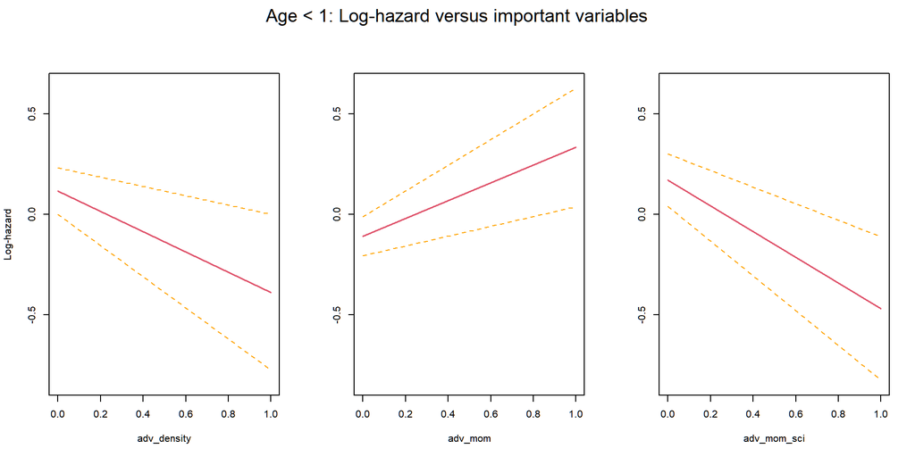

```r
plot_terms(full_age_below_1)
mtext("Age < 1: Log-hazard versus important variables", line=0, side=3, outer=TRUE, cex=1.2)
```

### Lasso

```r
penalized_below_1 <- get_penalized_covariates(age_below_1, below_one = TRUE)
opt_lambda_below_1 <- get_opt_lambda_of_lasso(
  data = age_below_1,
  penalized_covariates = penalized_below_1
)
nonzero_vars_below_1 <- get_nonzero_varnames_of_opt_lasso(
  data = age_below_1,
  penalized_covariates = penalized_below_1,
  opt_lambda = opt_lambda_below_1
)
vars_below_1 <- get_varnames_in_final_model(nonzero_vars_below_1)
lasso_age_below_1 <- run_cox(
  data = age_below_1,
  varnames = vars_below_1,
  penalized_covariates = penalized_below_1
)
round(summary(lasso_age_below_1)$coef, 3)
```

```
##                                 coef exp(coef) se(coef)      z Pr(>|z|)
## adv_densityTRUE               -0.772     0.462    0.339 -2.276    0.023
## adv_momTRUE                    0.410     1.507    0.232  1.770    0.077
## adv_mom_rankTRUE               0.265     1.303    0.216  1.226    0.220
## adv_mom_sciTRUE               -0.441     0.643    0.282 -1.562    0.118
## adv_rainTRUE                  -0.079     0.924    0.337 -0.234    0.815
## adv_densityTRUE:adv_momTRUE    0.825     2.281    0.510  1.618    0.106
## adv_mom_rankTRUE:adv_rainTRUE -1.254     0.285    1.078 -1.163    0.245
## adv_momTRUE:adv_mom_sciTRUE   -0.676     0.509    0.557 -1.214    0.225
```

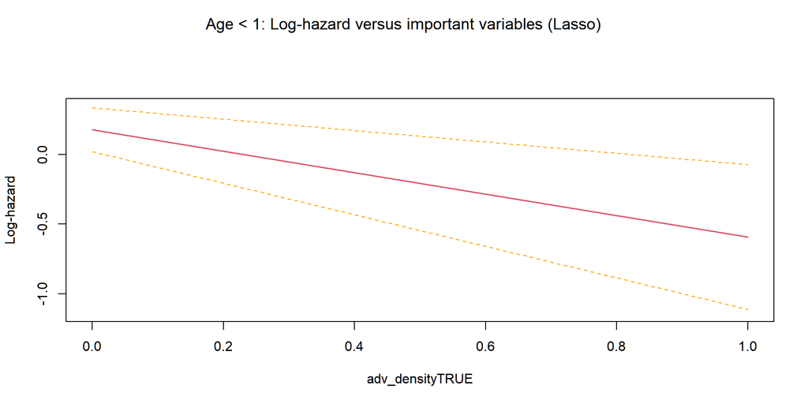

```r
plot_terms(lasso_age_below_1)
mtext("Age < 1: Log-hazard versus important variables (Lasso)", line=0, side=3, outer=TRUE, cex=1.2)
```

### Stepwise-BIC

```r
stepBIC_age_below_1 <- get_stepBIC(age_below_1, below_one=TRUE)
round(summary(stepBIC_age_below_1)$coef, 3)
```

```
##                   coef exp(coef) se(coef)      z Pr(>|z|)
## adv_mom_sciTRUE -0.588     0.555     0.24 -2.447    0.014
```

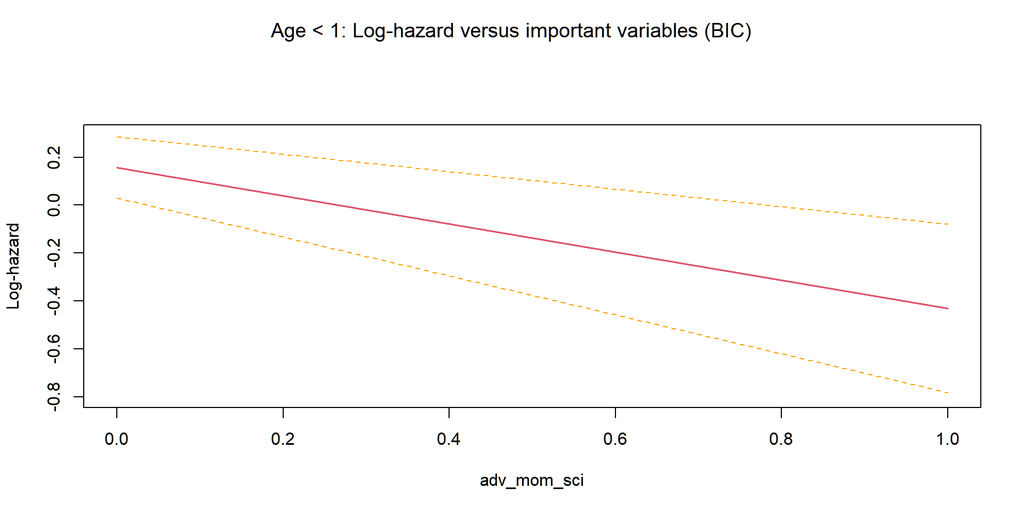

```r
plot_terms(stepBIC_age_below_1)
mtext("Age < 1: Log-hazard versus important variables (BIC)", line=0, side=3, outer=TRUE, cex=1.2)
```

### Cumulative

```r
cumulative_age_below_1 <- get_cumulative(age_below_1, below_one=TRUE)
round(summary(cumulative_age_below_1)$coef, 3)
```

```
##                                       coef exp(coef) se(coef)      z Pr(>|z|)
## adv_momTRUE                          0.497     1.644    0.290  1.717    0.086
## adv_other_cumulative1               -0.293     0.746    0.244 -1.203    0.229
## adv_other_cumulative2               -0.584     0.558    0.369 -1.583    0.113
## adv_other_cumulative2+              -0.511     0.600    0.725 -0.706    0.480
## adv_momTRUE:adv_other_cumulative1   -0.060     0.942    0.425 -0.141    0.888
## adv_momTRUE:adv_other_cumulative2    0.346     1.414    0.581  0.596    0.551
## adv_momTRUE:adv_other_cumulative2+ -16.132     0.000 2222.416 -0.007    0.994
```

## Age above 1 and below 5

### Main effects

```r
full_age_above_1_below_5 <- get_full(age_above_1_below_5, below_one = FALSE)
round(summary(full_age_above_1_below_5)$coef, 3)
```

```
##                    coef exp(coef) se(coef)      z Pr(>|z|)
## adv_densityTRUE  -0.006     0.994    0.243 -0.024    0.981
## adv_rainTRUE     -0.330     0.719    0.339 -0.976    0.329
## adv_momTRUE       0.789     2.201    0.217  3.634    0.000
## adv_sibTRUE      -0.054     0.948    0.279 -0.192    0.847
## adv_mom_rankTRUE  0.197     1.217    0.245  0.802    0.423
## adv_mom_sciTRUE  -0.278     0.757    0.243 -1.143    0.253
```

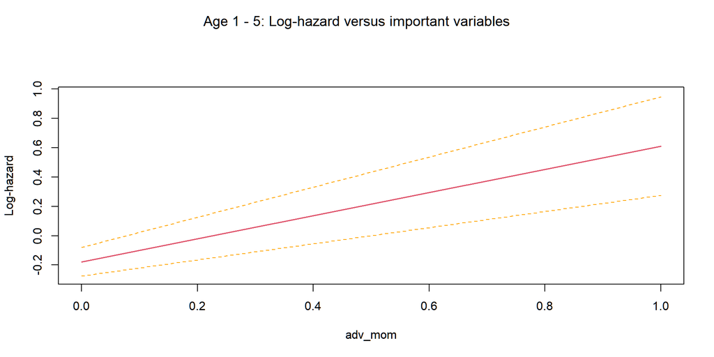

```r
plot_terms(full_age_above_1_below_5)
mtext("Age 1 - 5: Log-hazard versus important variables", line=0, side=3, outer=TRUE, cex=1.2)
```

### Lasso

```r
penalized_above_1_below_5 <- get_penalized_covariates(age_above_1_below_5, below_one = FALSE)
opt_lambda_above_1_below_5 <- get_opt_lambda_of_lasso(
  data = age_above_1_below_5,
  penalized_covariates = penalized_above_1_below_5
)
nonzero_vars_above_1_below_5 <- get_nonzero_varnames_of_opt_lasso(
  data = age_above_1_below_5,
  penalized_covariates = penalized_above_1_below_5,
  opt_lambda = opt_lambda_above_1_below_5
)
vars_above_1_below_5 <- get_varnames_in_final_model(nonzero_vars_above_1_below_5)
lasso_age_above_1_below_5 <- run_cox(
  data = age_above_1_below_5,
  varnames = vars_above_1_below_5,
  penalized_covariates = penalized_above_1_below_5
)
round(summary(lasso_age_above_1_below_5)$coef, 3)
```

```
##                                coef exp(coef) se(coef)      z Pr(>|z|)
## adv_momTRUE                   0.551     1.734    0.260  2.118    0.034
## adv_densityTRUE              -0.228     0.796    0.270 -0.843    0.399
## adv_sibTRUE                  -0.249     0.779    0.330 -0.755    0.450
## adv_mom_rankTRUE             -0.135     0.873    0.335 -0.404    0.686
## adv_densityTRUE:adv_sibTRUE   1.259     3.520    0.606  2.076    0.038
## adv_momTRUE:adv_mom_rankTRUE  0.692     1.999    0.495  1.399    0.162
```

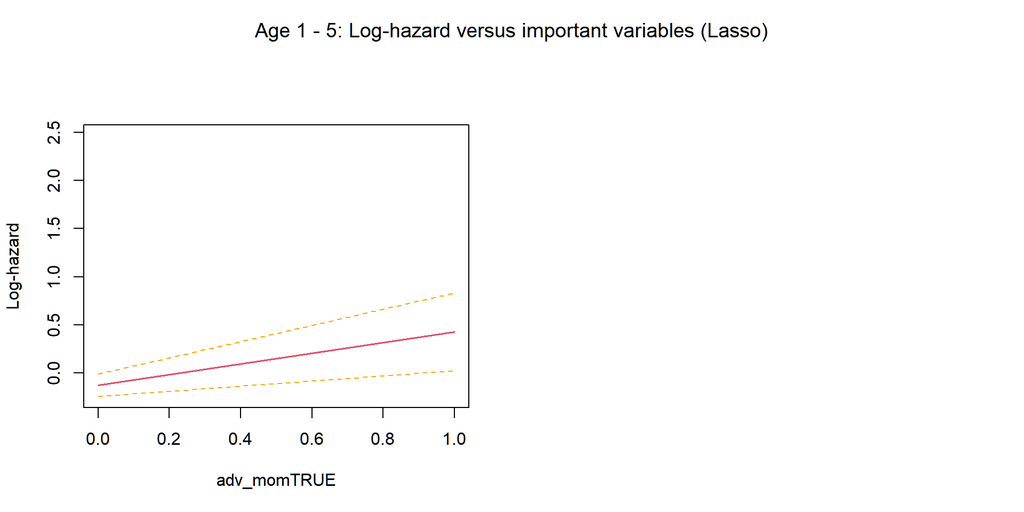

```r
plot_terms(lasso_age_above_1_below_5)
mtext("Age 1 - 5: Log-hazard versus important variables (Lasso)", line=0, side=3, outer=TRUE, cex=1.2)
```

### Stepwise-BIC

```r
stepBIC_age_above_1_below_5 <- get_stepBIC(age_above_1_below_5, below_one=FALSE)
round(summary(stepBIC_age_above_1_below_5)$coef, 3)
```

```
##              coef exp(coef) se(coef)     z Pr(>|z|)
## adv_momTRUE 0.765      2.15    0.216 3.543        0
```

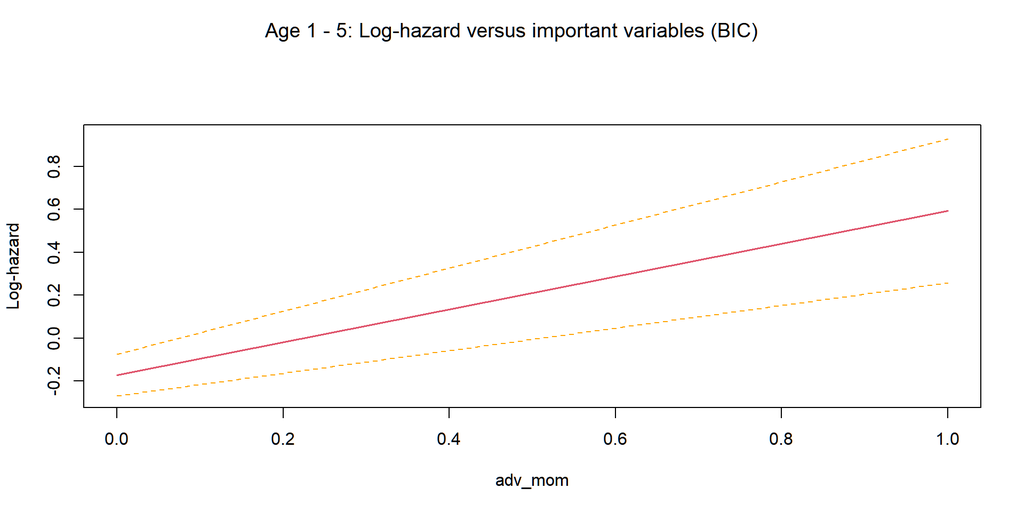

```r
plot_terms(stepBIC_age_above_1_below_5)
mtext("Age 1 - 5: Log-hazard versus important variables (BIC)", line=0, side=3, outer=TRUE, cex=1.2)
```

### Cumulative

```r
cumulative_age_above_1_below_5 <- get_cumulative(age_above_1_below_5)
round(summary(cumulative_age_above_1_below_5)$coef, 3)
```

```
##                                      coef exp(coef) se(coef)      z Pr(>|z|)
## adv_momTRUE                         0.336     1.399    0.434  0.773    0.440
## adv_other_cumulative1              -0.496     0.609    0.309 -1.606    0.108
## adv_other_cumulative2              -0.381     0.683    0.369 -1.031    0.302
## adv_other_cumulative2+              0.165     1.179    0.495  0.333    0.739
## adv_momTRUE:adv_other_cumulative1   0.891     2.439    0.545  1.635    0.102
## adv_momTRUE:adv_other_cumulative2   0.536     1.710    0.625  0.858    0.391
## adv_momTRUE:adv_other_cumulative2+ -1.088     0.337    1.178 -0.924    0.356
```

## Age above 5

### Main effects

```r
full_age_above_5 <- get_full(age_above_5, below_one = FALSE)
round(summary(full_age_above_5)$coef, 3)
```

```
##                    coef exp(coef) se(coef)      z Pr(>|z|)
## adv_densityTRUE   0.145     1.156    0.268  0.542    0.588
## adv_rainTRUE     -0.214     0.807    0.307 -0.696    0.487
## adv_momTRUE       0.732     2.079    0.225  3.250    0.001
## adv_sibTRUE       0.302     1.352    0.245  1.232    0.218
## adv_mom_rankTRUE  0.251     1.285    0.244  1.028    0.304
## adv_mom_sciTRUE   0.027     1.028    0.210  0.131    0.896
```

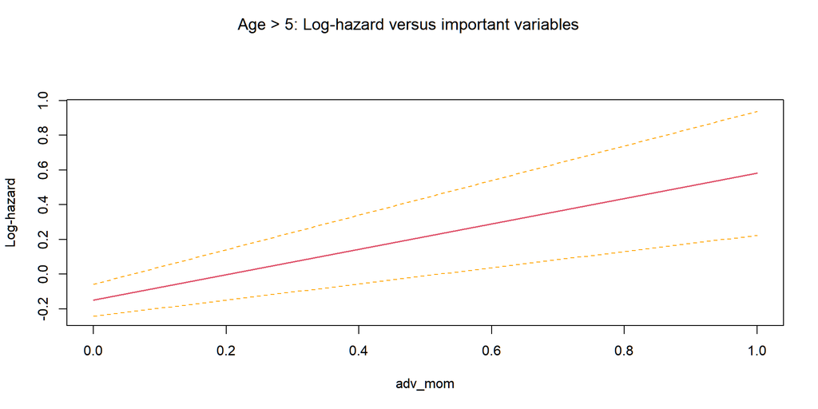

```r
plot_terms(full_age_above_5)
mtext("Age > 5: Log-hazard versus important variables", line=0, side=3, outer=TRUE, cex=1.2)
```

### Lasso

```r
penalized_above_5 <- get_penalized_covariates(age_above_5, below_one = FALSE)
opt_lambda_above_5 <- get_opt_lambda_of_lasso(
  data = age_above_5,
  penalized_covariates = penalized_above_5
)
nonzero_vars_above_5 <- get_nonzero_varnames_of_opt_lasso(
  data = age_above_5,
  penalized_covariates = penalized_above_5,
  opt_lambda = opt_lambda_above_5
)
vars_above_5 <- get_varnames_in_final_model(nonzero_vars_above_5)
lasso_age_above_5 <- run_cox(
  data = age_above_5,
  varnames = vars_above_5,
  penalized_covariates = penalized_above_5
)
round(summary(lasso_age_above_5)$coef, 3)
```

```
##                          coef exp(coef) se(coef)     z Pr(>|z|)
## adv_momTRUE             0.561     1.752    0.254 2.208    0.027
## adv_sibTRUE             0.146     1.157    0.289 0.506    0.613
## adv_momTRUE:adv_sibTRUE 0.587     1.799    0.507 1.158    0.247
```

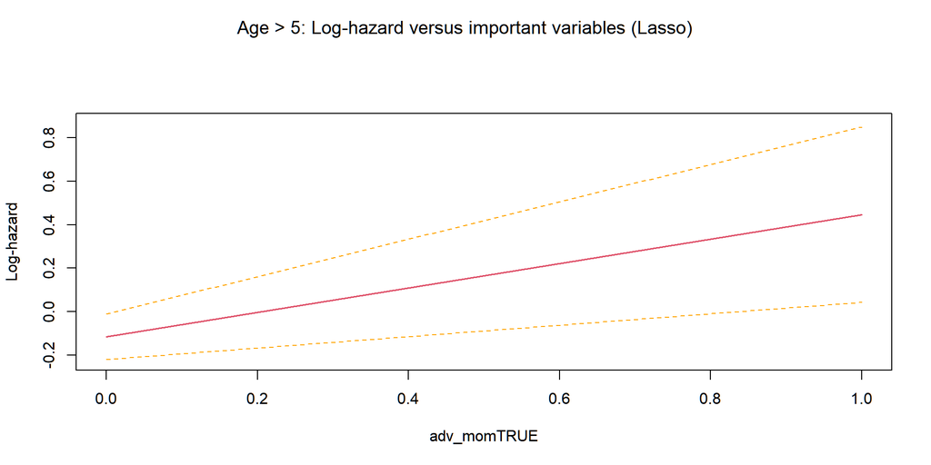

```r
plot_terms(lasso_age_above_5)
mtext("Age > 5: Log-hazard versus important variables (Lasso)", line=0, side=3, outer=TRUE, cex=1.2)
```

### Stepwise-BIC

```r
stepBIC_age_above_5 <- get_stepBIC(age_above_5, below_one=FALSE)
round(summary(stepBIC_age_above_5)$coef, 3)
```

```
##                            coef exp(coef) se(coef)      z Pr(>|z|)
## adv_rainTRUE              0.320     1.377    0.329  0.973    0.331
## adv_momTRUE               0.975     2.651    0.234  4.162    0.000
## adv_rainTRUE:adv_momTRUE -1.911     0.148    0.814 -2.346    0.019
```

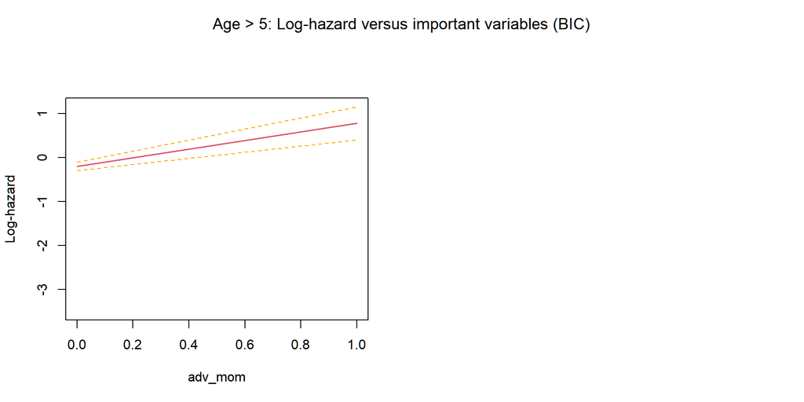

```r
plot_terms(stepBIC_age_above_5)
mtext("Age > 5: Log-hazard versus important variables (BIC)", line=0, side=3, outer=TRUE, cex=1.2)
```

### Cumulative

```r
cumulative_age_above_5 <- get_cumulative(age_above_5)
round(summary(cumulative_age_above_5)$coef, 3)
```

```
##                                      coef exp(coef) se(coef)      z Pr(>|z|)
## adv_momTRUE                         1.095     2.990    0.450  2.433    0.015
## adv_other_cumulative1               0.563     1.756    0.282  1.994    0.046
## adv_other_cumulative2               0.321     1.378    0.361  0.888    0.374
## adv_other_cumulative2+              0.753     2.123    0.558  1.349    0.177
## adv_momTRUE:adv_other_cumulative1  -0.679     0.507    0.546 -1.243    0.214
## adv_momTRUE:adv_other_cumulative2   0.124     1.132    0.647  0.192    0.848
## adv_momTRUE:adv_other_cumulative2+ -1.684     0.186    1.207 -1.395    0.163
```

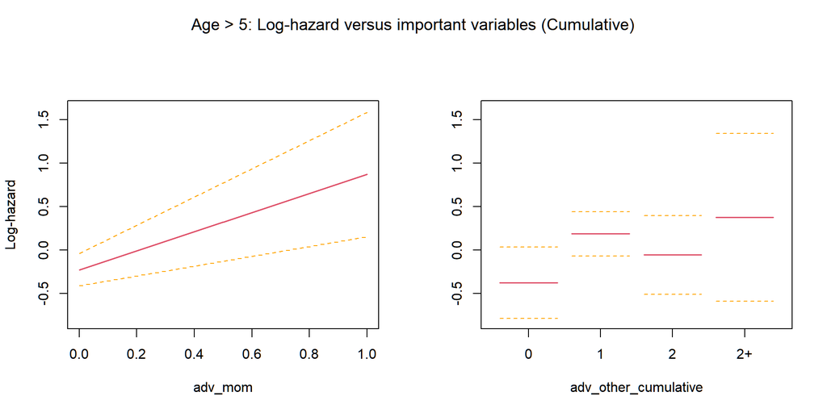

```r
plot_terms(cumulative_age_above_5)
mtext("Age > 5: Log-hazard versus important variables (Cumulative)", line=0, side=3, outer=TRUE, cex=1.2)
```